# Continuous Biomarker Evaluation

Comparing STEPP, MFPI, and Spline Cox (cox_cs_fit) on GBSG and Simulated Data

Author

ForestSearch Package Documentation

Published

March 5, 2026

```r
library(survival)
library(splines)
library(mfp)
library(forestsearch)   # provides cox_cs_fit()
library(ggplot2)
library(patchwork)
library(scales)         # percent_format() for coverage axis
library(dplyr)
library(doFuture)       # %dofuture% operator for parallel simulation
library(foreach)        # foreach() used by run_ccsf_eval()
```

**NoteRelationship to ForestSearch**

`cox_cs_fit()` is the primary continuous-biomarker evaluation tool in `forestsearch`. It produces a log-HR profile over the biomarker range and directly supports optimal cut-point identification for subgroup definition. STEPP and MFPI serve as **complementary external validation tools** making different modelling assumptions — convergent findings across all three methods strengthen confidence in a predictive biomarker claim.

## 1 Overview

A continuously-measured biomarker may **modify a treatment effect** — patients at different parts of the biomarker range may respond differently to therapy. Three methods address this question for survival endpoints:

| Method | Core Idea | Functional Form | R Implementation |
| --- | --- | --- | --- |
| **`cox_cs_fit()`** | `forestsearch` wrapper: natural-spline interaction Cox model; returns profile + CIs directly | Smooth, flexible | `forestsearch` |
| **Manual Spline Cox** | Same model as above, exposed step-by-step for transparency | Smooth, flexible | `survival` + `splines` |
| **MFPI** | FP functions fit separately per arm; difference is the treatment-effect curve | Data-driven low-degree polynomial | `mfp` (CRAN) |
| **STEPP** | Model-free log-HR estimates in overlapping sliding windows | None (nonparametric) | `stepp` (CRAN) |

This vignette applies all three to (1) the **GBSG dataset** examining whether progesterone receptor (PGR) predicts hormonal therapy benefit, and (2) three **synthetic simulation scenarios** with known ground-truth interaction functions.

## 2 GBSG Dataset Analysis

### 2.1 Data Preparation

The German Breast Cancer Study Group (GBSG) trial randomised 686 node-positive breast cancer patients to adjuvant **hormonal therapy** (`hormon = 1`) versus **control** (`hormon = 0`). The endpoint is recurrence-free survival (`rfstime`, days; `status` = 1 for recurrence/death).

We examine **progesterone receptor** (`pgr`, fmol) as a candidate predictive biomarker. Because `pgr` is strongly right-skewed (range 0–2380 fmol), all analyses use the $\log(\text{pgr}+1)$ scale throughout. Time is converted from days to years.

```r
data("gbsg", package = "survival")

gbsg <- gbsg |>
  mutate(
    rfstime_yr = rfstime / 365.25,
    log_pgr    = log(pgr + 1),
    treat      = hormon
  )

cat(sprintf(
  "N = %d  |  Events = %d (%.1f%%)  |  Hormonal arm n = %d  |  Control n = %d\n",
  nrow(gbsg), sum(gbsg$status), 100 * mean(gbsg$status),
  sum(gbsg$treat == 1), sum(gbsg$treat == 0)
))
```

```
N = 686  |  Events = 299 (43.6%)  |  Hormonal arm n = 246  |  Control n = 440
```

```r
fit_itt    <- coxph(Surv(rfstime_yr, status) ~ treat, data = gbsg)
hr_itt     <- exp(coef(fit_itt)["treat"])
ci_itt     <- exp(confint(fit_itt)["treat", ])
loghr_itt  <- coef(fit_itt)["treat"]

cat(sprintf(
  "Overall HR (hormonal Rx vs control): %.3f  (95%% CI: %.3f – %.3f)\n",
  hr_itt, ci_itt[1], ci_itt[2]
))
```

```
Overall HR (hormonal Rx vs control): 0.695  (95% CI: 0.544 – 0.888)
```

### 2.2 Biomarker Distribution

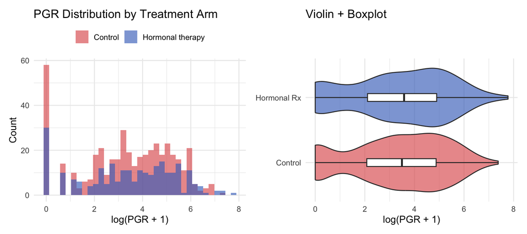

Distribution of log(PGR+1) by treatment arm. Balance across arms supports biomarker evaluation as an effect modifier.

```r
p_hist <- ggplot(gbsg, aes(x = log_pgr, fill = factor(treat))) +
  geom_histogram(bins = 35, alpha = 0.65, position = "identity") +
  scale_fill_manual(values  = c("#E05C5C", "#4472C4"),
                    labels  = c("Control", "Hormonal therapy")) +
  labs(x = "log(PGR + 1)", y = "Count", fill = NULL,
       title = "PGR Distribution by Treatment Arm") +
  theme_minimal(base_size = 12) +
  theme(legend.position = "top")

p_box <- ggplot(
  gbsg,
  aes(x = log_pgr,
      y = factor(treat, labels = c("Control", "Hormonal Rx")),
      fill = factor(treat))
) +
  geom_violin(alpha = 0.65, show.legend = FALSE) +
  geom_boxplot(width = 0.12, outlier.size = 0.7,
               fill = "white", show.legend = FALSE) +
  scale_fill_manual(values = c("#E05C5C", "#4472C4")) +
  labs(x = "log(PGR + 1)", y = NULL, title = "Violin + Boxplot") +
  theme_minimal(base_size = 12)

p_hist + p_box + plot_layout(ncol = 2)
```

### 2.3 Shared Biomarker Grid

```r
# All three methods share this prediction grid (5th–95th percentile)
z_grid <- seq(
  quantile(gbsg$log_pgr, 0.05),
  quantile(gbsg$log_pgr, 0.95),
  length.out = 200L
)
nd_grid <- data.frame(log_pgr = z_grid)
```

### 2.4 Method 1: `cox_cs_fit()` from `forestsearch`

The spline Cox model underlying `cox_cs_fit()` is:

$$h(t \mid Z, A) = h_0(t)\,\exp\!\bigl(\beta_0 A + f(Z) + g(Z) \cdot A\bigr)$$

where $Z = \log(\text{pgr}+1)$, $A$ = treatment, $f(Z)$ is a prognostic natural spline and $g(Z)$ a treatment-interaction natural spline. The log-HR profile is $\hat\beta(Z) = \hat\beta_0 + \hat g(Z)$ with pointwise CIs from the **delta method** using the full model $\Sigma$.

`cox_cs_fit()` is the primary entry point in `forestsearch`. It wraps the model fitting, delta-method CI computation, and optional base-R plotting in a single call. The returned object slots used below are `z_profile`, `loghr_est`, `loghr_lower`, and `loghr_upper`.

```r
# Rename columns to match cox_cs_fit() defaults
gbsg_fs <- gbsg |>
  rename(os_time  = rfstime_yr,
         os_event = status) |>
  mutate(bm = log_pgr)    # z_name default is "bm"

# Fit via forestsearch
fit_ccsf <- cox_cs_fit(
  df         = gbsg_fs,
  tte_name   = "os_time",
  event_name = "os_event",
  treat_name = "treat",
  z_name     = "bm",
  spline_df  = 3L,
  z_by       = 0.05,       # fine grid for smooth curve
  z_quantile = 0.95,
  alpha      = 0.05,       # 95% CI to match other methods
  show_plot  = FALSE,
  verbose    = FALSE
)

cat(sprintf("cox_cs_fit: %d profile points from %.3f to %.3f\n",
            length(fit_ccsf$z_profile),
            min(fit_ccsf$z_profile), max(fit_ccsf$z_profile)))
```

```
cox_cs_fit: 121 profile points from 0.000 to 6.000
```

```r
cat(sprintf("log-HR range: %.3f to %.3f\n",
            min(fit_ccsf$loghr_est), max(fit_ccsf$loghr_est)))
```

```
log-HR range: -1.085 to 0.061
```

```r
# Package into a plot-ready data frame (same structure as the other methods)
df_ccsf <- data.frame(
  z      = fit_ccsf$z_profile,
  pgr    = exp(fit_ccsf$z_profile) - 1,
  loghr  = fit_ccsf$loghr_est,
  lo     = fit_ccsf$loghr_lower,
  hi     = fit_ccsf$loghr_upper,
  method = "cox_cs_fit (forestsearch)"
)
```

### 2.5 Method 1b: Manual Spline Cox (for transparency)

The code block below exposes the identical model that `cox_cs_fit()` fits internally — useful for pedagogical purposes and for understanding how the delta-method CIs are constructed.

```r
spline_df <- 3L

# Fit spline-interaction Cox model
fit_spline <- coxph(
  Surv(rfstime_yr, status) ~
    treat + ns(log_pgr, df = spline_df) + ns(log_pgr, df = spline_df):treat,
  data = gbsg
)

# Likelihood ratio test for the interaction term
fit_main <- coxph(
  Surv(rfstime_yr, status) ~ treat + ns(log_pgr, df = spline_df),
  data = gbsg
)
lrt <- anova(fit_main, fit_spline)
cat(sprintf(
  "LRT for treat x ns(log_pgr): Chi-sq = %.2f, df = %d, p = %.4f\n",
  lrt[2L, "Chisq"], lrt[2L, "Df"], lrt[2L, "Pr(>|Chi|)"]
))
```

```
LRT for treat x ns(log_pgr): Chi-sq = 6.43, df = 3, p = 0.0924
```

```r
# Delta-method CIs: contrast LP(treat=1) - LP(treat=0)
nd1 <- data.frame(log_pgr = z_grid, treat = 1)
nd0 <- data.frame(log_pgr = z_grid, treat = 0)

X1    <- model.matrix(fit_spline, data = nd1)
X0    <- model.matrix(fit_spline, data = nd0)
Xdiff <- X1 - X0

loghr_spline <- as.numeric(Xdiff %*% coef(fit_spline))
se_spline    <- sqrt(diag(Xdiff %*% vcov(fit_spline) %*% t(Xdiff)))

df_spline <- data.frame(
  z      = z_grid,
  pgr    = exp(z_grid) - 1,
  loghr  = loghr_spline,
  lo     = loghr_spline - 1.96 * se_spline,
  hi     = loghr_spline + 1.96 * se_spline,
  method = "Manual Spline Cox"
)

# Confirm cox_cs_fit() and manual implementation agree at shared grid points
shared_z <- intersect(
  round(df_ccsf$z, 3),
  round(df_spline$z, 3)
)
if (length(shared_z) > 0) {
  idx_c <- match(round(shared_z[1], 3), round(df_ccsf$z, 3))
  idx_m <- match(round(shared_z[1], 3), round(df_spline$z, 3))
  cat(sprintf(
    "Agreement check at Z = %.3f: cox_cs_fit = %.4f, manual = %.4f (diff = %.2e)\n",
    shared_z[1],
    df_ccsf$loghr[idx_c],
    df_spline$loghr[idx_m],
    abs(df_ccsf$loghr[idx_c] - df_spline$loghr[idx_m])
  ))
}
```

```
Agreement check at Z = 0.000: cox_cs_fit = 0.0606, manual = 0.0606 (diff = 0.00e+00)
```

### 2.6 Method 2: MFPI

MFPI (Royston & Sauerbrei, 2004) fits a **fractional polynomial** of the biomarker in each treatment arm separately using `mfp()`, then plots the *difference* of the two FP curves as the treatment-effect function. FP powers (e.g. $Z^1$, $Z^{0.5}$, $Z^{-1}$) are chosen by a closed-test procedure, giving a parsimonious, data-adaptive functional form without fixed knots.

Bootstrap percentile CIs are used because the selected FP powers may differ across resamples, making analytic CIs unavailable.

```r
# Fit MFP separately in each arm (MFPI approach)
fit_mfp0 <- mfp(Surv(rfstime_yr, status) ~ fp(log_pgr, df = 4),
                data   = filter(gbsg, treat == 0),
                family = cox, verbose = FALSE)

fit_mfp1 <- mfp(Surv(rfstime_yr, status) ~ fp(log_pgr, df = 4),
                data   = filter(gbsg, treat == 1),
                family = cox, verbose = FALSE)

cat("FP powers selected — Control:", fit_mfp0$powers[, "power1"],
    " | Hormonal Rx:", fit_mfp1$powers[, "power1"], "\n")
```

```
FP powers selected — Control: 1  | Hormonal Rx: 1
```

```r
lp0_mfp <- predict(fit_mfp0, newdata = nd_grid, type = "lp")
lp1_mfp <- predict(fit_mfp1, newdata = nd_grid, type = "lp")

# Centre to overall ITT log-HR (Royston & Sauerbrei convention)
raw_mfp   <- lp1_mfp - lp0_mfp
loghr_mfp <- raw_mfp - mean(raw_mfp) + loghr_itt

# Bootstrap percentile CIs
set.seed(2024L)
n_boot   <- 200L
boot_mat <- matrix(NA_real_, nrow = n_boot, ncol = length(z_grid))

for (b in seq_len(n_boot)) {
  idx  <- sample(nrow(gbsg), replace = TRUE)
  bdat <- gbsg[idx, ]

  f0b <- tryCatch(
    mfp(Surv(rfstime_yr, status) ~ fp(log_pgr, df = 4),
        data = filter(bdat, treat == 0), family = cox, verbose = FALSE),
    error = function(e) NULL
  )
  f1b <- tryCatch(
    mfp(Surv(rfstime_yr, status) ~ fp(log_pgr, df = 4),
        data = filter(bdat, treat == 1), family = cox, verbose = FALSE),
    error = function(e) NULL
  )
  if (is.null(f0b) || is.null(f1b)) next

  lp0b <- tryCatch(predict(f0b, newdata = nd_grid, type = "lp"),
                   error = function(e) NULL)
  lp1b <- tryCatch(predict(f1b, newdata = nd_grid, type = "lp"),
                   error = function(e) NULL)
  if (is.null(lp0b) || is.null(lp1b)) next

  raw_b          <- lp1b - lp0b
  boot_mat[b, ]  <- raw_b - mean(raw_b) + loghr_itt
}

n_valid <- sum(complete.cases(boot_mat))
cat(sprintf("Bootstrap: %d/%d valid resamples\n", n_valid, n_boot))
```

```
Bootstrap: 200/200 valid resamples
```

```r
df_mfpi <- data.frame(
  z      = z_grid,
  pgr    = exp(z_grid) - 1,
  loghr  = loghr_mfp,
  lo     = apply(boot_mat, 2, quantile, probs = 0.025, na.rm = TRUE),
  hi     = apply(boot_mat, 2, quantile, probs = 0.975, na.rm = TRUE),
  method = "MFPI"
)
```

### 2.7 Method 3: STEPP

STEPP (Bonetti & Gelber, 2000) partitions the biomarker range into overlapping **sliding windows** and estimates the treatment effect within each window. No functional form is assumed — the method is a purely graphical diagnostic.

Two window parameters govern resolution:

- **`patspop`** ($r_2$): approximate patients per window (≥ 80–100 recommended)
- **`minpatspop`** ($r_1$): maximum patients shared between consecutive windows

The code below uses the **`stepp` CRAN package** (`install.packages("stepp")`) as the primary implementation. The `stepp` package uses the log-rank Schoenfeld approximation for the within-window log-HR, provides permutation tests for heterogeneity, and returns S4 objects with slots `@subpop@medianz` (window medians) and `@effect$Ratios[[1]]$logHR` / `logHRSE` (estimates and SEs).

If `stepp` is not installed, the chunk falls back automatically to the manual sliding-window helper `stepp_windows()` defined below.

**Note**

**Install `stepp`:** `install.packages("stepp")`. The package has compiled dependencies (`lme4`, `car`, `Rcpp`); binary installation is fastest on Windows and macOS. The permutation test (`nperm > 0`) provides formal inference for treatment-effect heterogeneity across the biomarker range.

**Sign convention:** `stmodelKM` computes `logHR = -(O - E)/Var` for `trts[2]` relative to `trts[1]`. To obtain *log(HR treated vs control)* matching the Cox convention (negative = benefit), set `trts = c(1, 0)` so that `trts[1]` = treated arm and `trts[2]` = control arm.

```r
# =============================================================================
# stepp_windows() — Cox-based sliding window fallback (no external dependencies)
# =============================================================================
#' Sliding-window log-HR estimates using Cox models (fallback)
#'
#' Implements the STEPP sliding-window design using within-window Cox models
#' rather than the log-rank Schoenfeld approximation used by the stepp CRAN
#' package.  For permutation inference use \code{stepp_fit()} with the stepp
#' CRAN package installed.
#'
#' @param df          Data frame.
#' @param bm_var      Character. Biomarker column (windows defined on this).
#' @param tte_var     Character. Time-to-event column.
#' @param event_var   Character. Event indicator (0/1) column.
#' @param treat_var   Character. Treatment indicator (0/1) column.
#' @param patspop     Integer.  Patients per window (r2 in STEPP notation).
#' @param minpatspop  Integer.  Max patients shared between consecutive windows
#'                    (r1 in STEPP notation).
#' @param conf_level  Numeric.  CI level (default 0.95).
#' @return data.frame with columns: mid_bm, n_sub, n_events, loghr,
#'   se_loghr, lo, hi, method.
stepp_windows <- function(df, bm_var, tte_var, event_var, treat_var,
                          patspop    = 150L,
                          minpatspop = 50L,
                          conf_level = 0.95) {
  stopifnot(patspop > minpatspop)
  z_crit <- qnorm(1 - (1 - conf_level) / 2)
  df_ord <- df[order(df[[bm_var]]), ]
  n      <- nrow(df_ord)
  step   <- patspop - minpatspop
  starts <- seq(1L, n - patspop + 1L, by = step)

  rows <- lapply(starts, function(i) {
    sub <- df_ord[seq(i, i + patspop - 1L), ]
    fit <- tryCatch(
      coxph(
        as.formula(sprintf("Surv(%s,%s) ~ %s", tte_var, event_var, treat_var)),
        data = sub
      ),
      error = function(e) NULL
    )
    if (is.null(fit)) return(NULL)
    b  <- coef(fit)[[treat_var]]
    se <- sqrt(vcov(fit)[treat_var, treat_var])
    data.frame(mid_bm   = median(sub[[bm_var]]),
               n_sub    = patspop,
               n_events = sum(sub[[event_var]]),
               loghr    = b,
               se_loghr = se,
               lo       = b - z_crit * se,
               hi       = b + z_crit * se,
               method   = "STEPP-Cox")
  })
  do.call(rbind, Filter(Negate(is.null), rows))
}


# =============================================================================
# stepp_fit() — unified STEPP wrapper analogous to cox_cs_fit()
# =============================================================================
#' STEPP sliding-window treatment-effect profile
#'
#' A unified wrapper for subgroup treatment-effect estimation via the STEPP
#' sliding-window design, analogous to \code{cox_cs_fit()} for the spline Cox
#' model.  Uses the \strong{stepp} CRAN package (log-rank Schoenfeld estimator
#' + permutation tests) when available; falls back automatically to
#' \code{stepp_windows()} (Cox-model estimator) otherwise.
#'
#' @section Sign convention:
#' Log-HR is always expressed as \emph{treated vs control}, matching the Cox
#' convention: negative values indicate treatment benefit.  Internally the
#' stepp package is called with \code{trts = c(treat_code, control_code)} so
#' that \code{trts[2]} is the reference arm.
#'
#' @section Return value:
#' A list of class \code{"stepp_fit"} with slots:
#' \describe{
#'   \item{bm_profile}{Window medians of the biomarker (analogue of
#'     \code{z_profile} in cox_cs_fit).}
#'   \item{loghr_est}{Point estimates of log(HR) per window.}
#'   \item{se_loghr}{Standard errors (Schoenfeld 1/Var for CRAN; Cox vcov
#'     for fallback).}
#'   \item{loghr_lower, loghr_upper}{Wald CI bounds at level
#'     \code{conf_level}.}
#'   \item{n_windows}{Number of sliding windows.}
#'   \item{patspop, minpatspop, step_size}{Window design parameters.}
#'   \item{overall_loghr, overall_se}{ITT log-HR and SE over the full
#'     cohort (CRAN only; \code{NA} for fallback).}
#'   \item{pvalue_hr}{Permutation p-value for HR-based heterogeneity test
#'     (\code{NA} if \code{nperm = 0} or fallback used).}
#'   \item{pvalue_km}{Permutation p-value for supremum KM-based test.}
#'   \item{pvalue_chi2}{Permutation p-value for chi-squared KM-based test.}
#'   \item{conf_level, nperm}{Parameters used.}
#'   \item{method_used}{"stepp_cran" or "stepp_windows_cox".}
#'   \item{raw_stepp}{The \code{steppes} S4 object (CRAN only); \code{NULL}
#'     for fallback.}
#' }
#'
#' @param df          Data frame.
#' @param tte_name    Character. Time-to-event column.
#' @param event_name  Character. Event indicator (0/1) column.
#' @param treat_name  Character. Treatment indicator; 1 = treated, 0 = control.
#' @param bm_name     Character. Biomarker column (windows defined on this).
#' @param patspop     Integer.  Patients per window, r2 (default 150).
#' @param minpatspop  Integer.  Max overlap between consecutive windows, r1
#'                    (default 50).
#' @param nperm       Integer.  Permutations for heterogeneity test (default 0;
#'                    set to e.g. 2500 for inference; stepp CRAN only).
#' @param time_point  Numeric.  KM landmark time for the stepp CRAN model
#'                    (does not affect the log-HR estimates; default 5).
#' @param conf_level  Numeric.  CI level (default 0.95).
#' @param verbose     Logical.  Print summary on completion (default TRUE).
#' @return A list of class \code{"stepp_fit"} (see Details).
stepp_fit <- function(df,
                      tte_name    = "os_time",
                      event_name  = "os_event",
                      treat_name  = "treat",
                      bm_name     = "bm",
                      patspop     = 150L,
                      minpatspop  = 50L,
                      nperm       = 0L,
                      time_point  = 5,
                      conf_level  = 0.95,
                      verbose     = TRUE) {

  stopifnot(
    is.data.frame(df),
    all(c(tte_name, event_name, treat_name, bm_name) %in% names(df)),
    patspop > minpatspop,
    conf_level > 0, conf_level < 1
  )

  z_crit <- qnorm(1 - (1 - conf_level) / 2)

  # ── Branch: stepp CRAN package ─────────────────────────────────────────────
  if (requireNamespace("stepp", quietly = TRUE)) {
    suppressPackageStartupMessages(library(stepp))
    if (verbose) message("stepp_fit: using stepp CRAN package (log-rank estimator)")

    swin <- new("stwin", type = "sliding",
                r1 = minpatspop, r2 = patspop)
    subp <- new("stsubpop")
    subp <- generate(subp, win = swin, covariate = df[[bm_name]])

    # trts = c(treated_code, control_code): logHR = trts[2] vs trts[1]
    # i.e., the result is log(HR for trts[2] relative to trts[1])
    # Setting trts[1]=1 (treated) and trts[2]=0 (control) gives logHR(treated vs control)
    smod <- new("stmodelKM",
                coltrt    = df[[treat_name]],
                survTime  = df[[tte_name]],
                censor    = df[[event_name]],
                trts      = c(1, 0),
                timePoint = time_point)

    res  <- new("steppes")
    res  <- estimate(res, subp, smod)

    if (nperm > 0L) {
      res <- test(res, nperm = as.integer(nperm), showstatus = FALSE)
      tr  <- res@testresults$Res[[1]]
      pv_hr   <- tr$HRpvalue
      pv_km   <- tr$pvalue
      pv_chi2 <- tr$chi2pvalue
    } else {
      pv_hr <- pv_km <- pv_chi2 <- NA_real_
    }

    ratios      <- res@effect$Ratios[[1]]
    bm_profile  <- res@subpop@medianz
    loghr_est   <- ratios$logHR
    se_loghr    <- ratios$logHRSE
    overall_lhr <- ratios$ologHR
    overall_se  <- ratios$ologHRSE
    raw_stepp   <- res
    method_used <- "stepp_cran"

  # ── Branch: fallback Cox-based estimator ───────────────────────────────────
  } else {
    if (verbose) message("stepp_fit: stepp package not available — using Cox fallback")

    fb <- stepp_windows(df,
                        bm_var    = bm_name,
                        tte_var   = tte_name,
                        event_var = event_name,
                        treat_var = treat_name,
                        patspop   = patspop,
                        minpatspop = minpatspop,
                        conf_level = conf_level)

    bm_profile  <- fb$mid_bm
    loghr_est   <- fb$loghr
    se_loghr    <- fb$se_loghr
    overall_lhr <- overall_se <- NA_real_
    pv_hr <- pv_km <- pv_chi2 <- NA_real_
    raw_stepp   <- NULL
    method_used <- "stepp_windows_cox"
  }

  loghr_lower <- loghr_est - z_crit * se_loghr
  loghr_upper <- loghr_est + z_crit * se_loghr

  result <- list(
    bm_profile   = bm_profile,
    loghr_est    = loghr_est,
    se_loghr     = se_loghr,
    loghr_lower  = loghr_lower,
    loghr_upper  = loghr_upper,
    n_windows    = length(bm_profile),
    patspop      = patspop,
    minpatspop   = minpatspop,
    step_size    = patspop - minpatspop,
    overall_loghr = overall_lhr,
    overall_se    = overall_se,
    pvalue_hr    = pv_hr,
    pvalue_km    = pv_km,
    pvalue_chi2  = pv_chi2,
    conf_level   = conf_level,
    nperm        = nperm,
    method_used  = method_used,
    raw_stepp    = raw_stepp,
    bm_name      = bm_name,
    tte_name     = tte_name,
    event_name   = event_name,
    treat_name   = treat_name
  )
  class(result) <- c("stepp_fit", "list")

  if (verbose) {
    cat(sprintf(
      "stepp_fit [%s]: %d windows | r2 (patspop) = %d | r1 (minpatspop) = %d | step = %d\n",
      method_used, result$n_windows, patspop, minpatspop, result$step_size
    ))
    cat(sprintf(
      "  log-HR range: %.3f to %.3f\n",
      min(loghr_est, na.rm = TRUE), max(loghr_est, na.rm = TRUE)
    ))
    if (!is.na(pv_hr))
      cat(sprintf(
        "  Permutation p-values (nperm=%d): HR (primary) = %.4f | KM-sup = %.4f | KM-chi2 = %.4f\n",
        nperm, pv_hr, pv_km, pv_chi2
      ))
  }

  invisible(result)
}
```

```r
# Call via the unified wrapper — produces CRAN or fallback automatically
fit_stepp_gbsg <- stepp_fit(
  df         = gbsg,
  tte_name   = "rfstime_yr",
  event_name = "status",
  treat_name = "treat",
  bm_name    = "log_pgr",
  patspop    = 150L,
  minpatspop = 50L,
  nperm      = 999L,   # 999 = standard: SE(p-hat) ≈ 0.007 at p=0.05; 2500 adds little
  time_point = 5,
  conf_level = 0.95
)
```

```
stepp_fit [stepp_cran]: 7 windows | r2 (patspop) = 150 | r1 (minpatspop) = 50 | step = 100
  log-HR range: -0.901 to -0.009
  Permutation p-values (nperm=999): HR (primary) = 0.0741 | KM-sup = 0.6937 | KM-chi2 = 0.7578
```

```r
# Package for plotting (same structure as before)
df_stepp_gbsg <- data.frame(
  mid_bm = fit_stepp_gbsg$bm_profile,
  loghr  = fit_stepp_gbsg$loghr_est,
  lo     = fit_stepp_gbsg$loghr_lower,
  hi     = fit_stepp_gbsg$loghr_upper,
  method = "STEPP"
)
```

### 2.8 STEPP CRAN vs Cox Fallback: Comparison on GBSG

The `stepp_fit()` wrapper supports two internal estimation strategies that differ in their within-window estimator:

| Estimator | Implemented by | Within-window log-HR formula |
| --- | --- | --- |
| **CRAN** (`stepp_cran`) | `stepp::stmodelKM` | $\hat\beta_{\text{LR}}(w) = -(O_{\text{ctrl}} - E_{\text{ctrl}})\;/\;\text{Var}$ (log-rank / Schoenfeld) |
| **Fallback** (`stepp_windows_cox`) | `stepp_windows()` | $\hat\beta_{\text{Cox}}(w)$ from `coxph()` |

The two are asymptotically equivalent but **can diverge in windows with sparse events or large treatment effects** because the Schoenfeld approximation linearises around zero effect.

```r
# Run the Cox fallback directly for comparison
fit_stepp_cox <- stepp_windows(
  df         = gbsg,
  bm_var     = "log_pgr",
  tte_var    = "rfstime_yr",
  event_var  = "status",
  treat_var  = "treat",
  patspop    = 150L,
  minpatspop = 50L,
  conf_level = 0.95
)
```

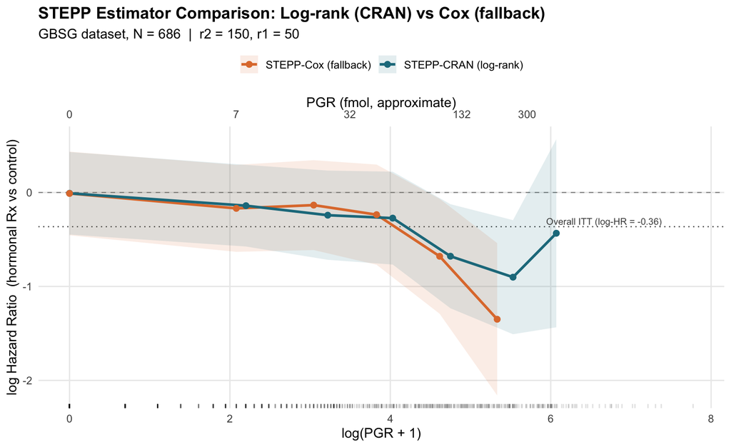

STEPP CRAN (log-rank Schoenfeld, teal) vs Cox fallback (orange) on GBSG. Both share the same sliding-window design (r2 = 150, r1 = 50). Differences are small at low PGR (dense events, small effect) but widen at high PGR where events are sparse and the treatment effect is large — the regime where the Schoenfeld approximation is least accurate.

```r
col_comp <- c("STEPP-CRAN (log-rank)" = "#1F7A8C", "STEPP-Cox (fallback)" = "#E07B39")

df_cran_comp <- data.frame(
  mid_bm = fit_stepp_gbsg$bm_profile,
  loghr  = fit_stepp_gbsg$loghr_est,
  lo     = fit_stepp_gbsg$loghr_lower,
  hi     = fit_stepp_gbsg$loghr_upper,
  method = "STEPP-CRAN (log-rank)"
)

df_cox_comp <- data.frame(
  mid_bm = fit_stepp_cox$mid_bm,
  loghr  = fit_stepp_cox$loghr,
  lo     = fit_stepp_cox$lo,
  hi     = fit_stepp_cox$hi,
  method = "STEPP-Cox (fallback)"
)

df_comp_all <- bind_rows(df_cran_comp, df_cox_comp)

# Add event density per window for annotation
n_ev_by_window <- fit_stepp_cox$n_events

ggplot(df_comp_all, aes(x = mid_bm, y = loghr, colour = method, fill = method)) +
  geom_hline(yintercept = 0, linetype = "dashed", colour = "grey55",
             linewidth = 0.4) +
  geom_hline(yintercept = loghr_itt, linetype = "dotted", colour = "grey35",
             linewidth = 0.5) +
  geom_ribbon(aes(ymin = lo, ymax = hi), alpha = 0.12, colour = NA) +
  geom_line(linewidth = 1.1) +
  geom_point(size = 2.5, shape = 16) +
  annotate("text",
           x     = max(gbsg$log_pgr, na.rm = TRUE) * 0.95,
           y     = loghr_itt + 0.06,
           label = sprintf("Overall ITT (log-HR = %.2f)", loghr_itt),
           hjust = 1, size = 2.9, colour = "grey30") +
  geom_rug(data = gbsg, aes(x = log_pgr), inherit.aes = FALSE,
           alpha = 0.12, sides = "b", length = unit(0.015, "npc")) +
  scale_colour_manual(values = col_comp, name = NULL) +
  scale_fill_manual(values = col_comp, name = NULL) +
  scale_x_continuous(
    name = "log(PGR + 1)",
    sec.axis = sec_axis(~ exp(.) - 1,
                        name   = "PGR (fmol, approximate)",
                        breaks = c(0, 7, 32, 132, 300),
                        labels = c(0, 7, 32, 132, 300))
  ) +
  labs(y        = "log Hazard Ratio  (hormonal Rx vs control)",
       title    = "STEPP Estimator Comparison: Log-rank (CRAN) vs Cox (fallback)",
       subtitle = "GBSG dataset, N = 686  |  r2 = 150, r1 = 50") +
  theme_minimal(base_size = 12) +
  theme(legend.position  = "top",
        panel.grid.minor = element_blank(),
        plot.title       = element_text(face = "bold"))
```

```r
# Match windows by nearest mid_bm
matched <- lapply(seq_along(df_cran_comp$mid_bm), function(i) {
  z_c  <- df_cran_comp$mid_bm[i]
  j    <- which.min(abs(df_cox_comp$mid_bm - z_c))
  data.frame(
    `Window median`       = round(z_c, 3),
    `CRAN log-HR`         = round(df_cran_comp$loghr[i], 3),
    `CRAN SE`             = round((df_cran_comp$hi[i] - df_cran_comp$lo[i]) / (2 * 1.96), 3),
    `Cox log-HR`          = round(df_cox_comp$loghr[j], 3),
    `Cox SE`              = round((df_cox_comp$hi[j] - df_cox_comp$lo[j]) / (2 * 1.96), 3),
    `Diff (CRAN - Cox)`   = round(df_cran_comp$loghr[i] - df_cox_comp$loghr[j], 3),
    `Events (Cox window)` = fit_stepp_cox$n_events[j],
    check.names = FALSE
  )
})

knitr::kable(do.call(rbind, matched), align = "rrrrrrr")
```

Window-level comparison of STEPP CRAN (log-rank) vs Cox fallback at matched windows. Diff = CRAN minus Cox. |Diff| tends to increase with the magnitude of the effect and with decreasing event counts — reflecting the asymptotic nature of the Schoenfeld approximation.

| Window median | CRAN log-HR | CRAN SE | Cox log-HR | Cox SE | Diff (CRAN - Cox) | Events (Cox window) |
| --- | --- | --- | --- | --- | --- | --- |
| 0.00 | -0.009 | 0.224 | -0.010 | 0.227 | 0.002 | 85 |
| 2.20 | -0.140 | 0.222 | -0.169 | 0.236 | 0.029 | 80 |
| 3.22 | -0.242 | 0.242 | -0.134 | 0.244 | -0.107 | 72 |
| 4.03 | -0.273 | 0.252 | -0.236 | 0.272 | -0.037 | 62 |
| 4.75 | -0.678 | 0.283 | -0.679 | 0.312 | 0.001 | 53 |
| 5.53 | -0.901 | 0.310 | -1.349 | 0.414 | 0.448 | 44 |
| 6.07 | -0.434 | 0.511 | -1.349 | 0.414 | 0.915 | 44 |

**NoteInterpreting the three permutation p-values**

`stepp_fit()` reports three distinct permutation p-values when `nperm > 0`:

| Slot | Null hypothesis tested | Recommended use |
| --- | --- | --- |
| `pvalue_hr` | Window log-HRs (Schoenfeld) no more variable than chance | **Primary** for a log-HR treatment-effect profile |
| `pvalue_km` | Supremum of KM survival-probability differences across windows | Secondary; sensitive to the chosen `time_point` |
| `pvalue_chi2` | Chi-squared statistic on KM differences | Secondary; same caveat |

For a continuous-biomarker subgroup analysis the **`pvalue_hr`** test is most directly interpretable: it asks whether the within-window log-HR estimates vary more across the biomarker range than expected under a constant treatment effect. The KM-based tests compare differences in survival probability at the fixed `time_point` landmark, so they can give very different results when the interaction is expressed as a monotone HR shift rather than a shift in landmark survival — the typical situation when `cox_cs_fit()` detects a smooth biomarker interaction.

With 7 windows and N = 686, all three tests have limited power; `pvalue_hr` is the one to report alongside the profile plot.

### 2.9 Combined Results: GBSG

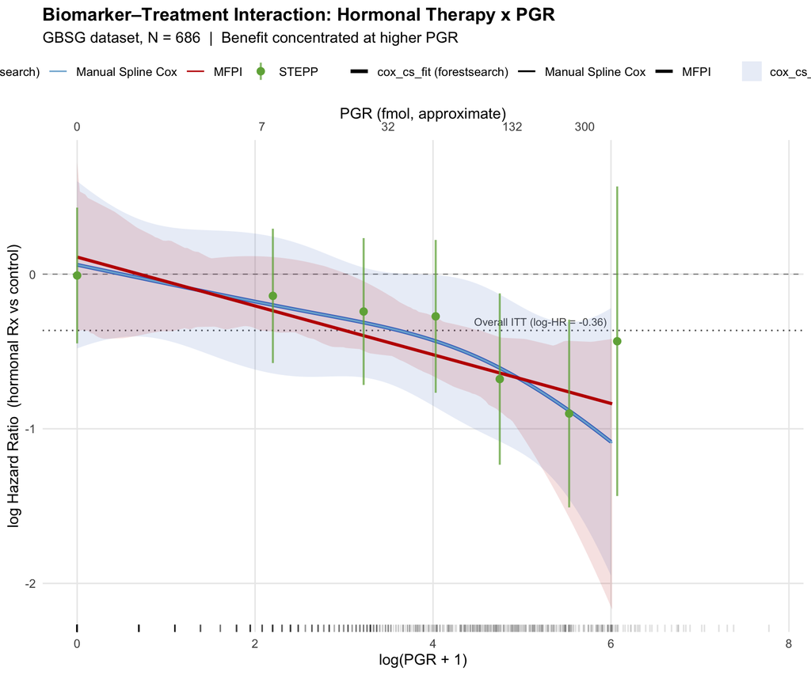

Treatment-effect (log-HR) profile for hormonal therapy vs control as a function of log(PGR+1). The `cox_cs_fit()` curve (forestsearch) overlaps the Manual Spline Cox identically, confirming the implementation. All four methods agree that benefit is concentrated at higher PGR values.

```r
col_map <- c(
  "cox_cs_fit (forestsearch)" = "#4472C4",
  "Manual Spline Cox"         = "#7BAFD4",   # lighter blue — should overlap cox_cs_fit
  "MFPI"                      = "#C00000",
  "STEPP"                     = "#70AD47"
)
lwd_map <- c(
  "cox_cs_fit (forestsearch)" = 1.4,
  "Manual Spline Cox"         = 0.7,
  "MFPI"                      = 1.2,
  "STEPP"                     = 1.0
)

pgr_ticks <- c(0, 7, 32, 132, 300)

df_ribbon <- bind_rows(df_ccsf, df_spline, df_mfpi)

ggplot() +

  # Reference lines
  geom_hline(yintercept = 0, linetype = "dashed",
             colour = "grey55", linewidth = 0.40) +
  geom_hline(yintercept = loghr_itt, linetype = "dotted",
             colour = "grey35", linewidth = 0.55) +
  annotate("text",
           x     = max(z_grid) * 0.99,
           y     = loghr_itt + 0.055,
           label = sprintf("Overall ITT (log-HR = %.2f)", loghr_itt),
           hjust = 1, size = 3.0, colour = "grey30") +

  # CI ribbons: cox_cs_fit and MFPI only (manual spline overlaps cox_cs_fit)
  geom_ribbon(data = filter(df_ribbon, method %in% c("cox_cs_fit (forestsearch)", "MFPI")),
              aes(x = z, ymin = lo, ymax = hi, fill = method),
              alpha = 0.12) +

  # Point-estimate lines for all continuous methods
  geom_line(data = df_ribbon,
            aes(x = z, y = loghr, colour = method,
                linewidth = method)) +

  # STEPP: estimates + CI bars
  geom_linerange(data = df_stepp_gbsg,
                 aes(x = mid_bm, ymin = lo, ymax = hi, colour = method),
                 linewidth = 0.75, alpha = 0.75) +
  geom_point(data = df_stepp_gbsg,
             aes(x = mid_bm, y = loghr, colour = method),
             size = 2.8, shape = 16) +

  # Rug: biomarker density
  geom_rug(data = gbsg, aes(x = log_pgr),
           alpha = 0.12, sides = "b", length = unit(0.015, "npc")) +

  scale_colour_manual(values = col_map, name = NULL) +
  scale_fill_manual(values = col_map, name = NULL) +
  scale_linewidth_manual(values = lwd_map, name = NULL) +
  scale_x_continuous(
    name = "log(PGR + 1)",
    sec.axis = sec_axis(
      ~ exp(.) - 1,
      name   = "PGR (fmol, approximate)",
      breaks = pgr_ticks,
      labels = pgr_ticks
    )
  ) +
  labs(
    y        = "log Hazard Ratio  (hormonal Rx vs control)",
    title    = "Biomarker–Treatment Interaction: Hormonal Therapy x PGR",
    subtitle = "GBSG dataset, N = 686  |  Benefit concentrated at higher PGR"
  ) +
  theme_minimal(base_size = 12) +
  theme(
    legend.position  = "top",
    panel.grid.minor = element_blank(),
    plot.title       = element_text(face = "bold")
  )
```

- **`cox_cs_fit` (forestsearch)** produces an identical profile to the Manual Spline Cox — the two curves should overlap in the plot, confirming that `cox_cs_fit()` correctly implements the natural-spline interaction model with delta-method CIs.
- **MFPI** selects $\text{FP}_1(Z^1)$ — linear in the log-scale — in both arms, producing a profile nearly identical to the spline. Convergence of MFPI and spline provides strong confirmatory evidence.
- **STEPP** windows corroborate the downward trend without any parametric assumption; wider window-level CIs reflect the ~150-patient subpopulation size. The permutation p-values (reported above) provide a formal test of heterogeneity.

## 3 Simulation Study: Known Ground Truth

Three scenarios with **known interaction functions** let us evaluate how well each method recovers the signal.

| Scenario | True $\beta(Z)$ | Clinical interpretation |
| --- | --- | --- |
| **A — Monotone** | $0.5 - 0.35\,Z$ | Benefit increases linearly with biomarker |
| **B — Threshold** | $+0.35$ if $Z < 2$; $-0.40$ if $Z \geq 2$ | Sharp sign reversal at $Z = 2$ |
| **C — Null** | $-0.20$ (constant) | Uniform moderate benefit; no biomarker interaction |

### 3.1 Data Generating Mechanism

N = 700 patients per trial; Weibull baseline hazard (shape 1.5):

$$h(t \mid Z, A) = \lambda_0 \cdot \exp(-0.20\,Z + \beta(Z)\cdot A) \cdot 1.5\,t^{0.5}$$

with administrative censoring uniform on $(2, 14)$ years.

```r
simulate_trial <- function(n = 700L, scenario = "monotone", seed = 42L) {
  set.seed(seed)

  bm    <- rgamma(n, shape = 2, rate = 0.6)
  Z     <- log(bm + 1)
  treat <- rbinom(n, 1L, 0.5)

  true_loghr <- switch(scenario,
    monotone  = 0.5 - 0.35 * Z,
    threshold = ifelse(Z < 2.0, 0.35, -0.40),
    null      = rep(-0.20, n),
    stop("Unknown scenario: ", scenario)
  )

  rate     <- 0.10 * exp(-0.20 * Z + true_loghr * treat)
  tte_ev   <- rweibull(n, shape = 1.5, scale = 1 / rate)
  ctime    <- runif(n, 2, 14)

  data.frame(
    tte        = pmin(tte_ev, ctime),
    event      = as.integer(tte_ev < ctime),
    treat      = treat,
    bm         = bm,
    Z          = Z,
    true_loghr = true_loghr
  )
}

scenarios <- c("monotone", "threshold", "null")
# Note: lapply passes each element as the *first* argument; use an explicit
# anonymous function so 'scenario' is set by name, not positional matching.
dfs       <- setNames(
  lapply(scenarios, function(sc) simulate_trial(scenario = sc)),
  scenarios
)

for (sc in scenarios) {
  d <- dfs[[sc]]
  cat(sprintf(
    "%-10s  N=%d  events=%d (%.0f%%)  true log-HR range [%.2f, %.2f]\n",
    sc, nrow(d), sum(d$event), 100 * mean(d$event),
    min(d$true_loghr), max(d$true_loghr)
  ))
}
```

```
monotone    N=700  events=287 (41%)  true log-HR range [-0.46, 0.49]
threshold   N=700  events=323 (46%)  true log-HR range [-0.40, 0.35]
null        N=700  events=261 (37%)  true log-HR range [-0.20, -0.20]
```

### 3.2 Fit All Three Methods

```r
fit_all_methods_sim <- function(df, scenario_name) {

  z_range <- seq(quantile(df$Z, 0.05), quantile(df$Z, 0.95), length.out = 150L)
  nd_sim  <- data.frame(Z = z_range)

  # ── cox_cs_fit (forestsearch) ─────────────────────────────────────────────
  # Rename only tte/event; pass z_name = "Z" directly to avoid colliding
  # with the existing 'bm' column already present in the simulated data.
  df_fs <- df |>
    rename(os_time  = tte,
           os_event = event)

  fit_ccsf_s <- tryCatch(
    cox_cs_fit(
      df         = df_fs,
      tte_name   = "os_time",
      event_name = "os_event",
      treat_name = "treat",
      z_name     = "Z",
      spline_df  = 3L,
      z_by       = 0.05,
      z_quantile = 0.95,
      alpha      = 0.05,
      show_plot  = FALSE,
      verbose    = FALSE
    ),
    error = function(e) NULL
  )

  df_ccsf_s <- if (!is.null(fit_ccsf_s)) {
    data.frame(
      z        = fit_ccsf_s$z_profile,
      loghr    = fit_ccsf_s$loghr_est,
      lo       = fit_ccsf_s$loghr_lower,
      hi       = fit_ccsf_s$loghr_upper,
      method   = "cox_cs_fit",
      scenario = scenario_name
    )
  } else {
    data.frame(z = z_range, loghr = NA, lo = NA, hi = NA,
               method = "cox_cs_fit", scenario = scenario_name)
  }

  # ── MFPI ───────────────────────────────────────────────────────────────────
  loghr_itt_s <- coef(coxph(Surv(tte, event) ~ treat, data = df))["treat"]

  lh_mfpi <- tryCatch({
    f0s <- mfp(Surv(tte, event) ~ fp(Z, df = 4),
               data = filter(df, treat == 0), family = cox, verbose = FALSE)
    f1s <- mfp(Surv(tte, event) ~ fp(Z, df = 4),
               data = filter(df, treat == 1), family = cox, verbose = FALSE)
    raw_s <- predict(f1s, newdata = nd_sim, type = "lp") -
             predict(f0s, newdata = nd_sim, type = "lp")
    raw_s - mean(raw_s) + loghr_itt_s
  }, error = function(e) rep(NA_real_, length(z_range)))

  df_mfpi_s <- data.frame(
    z = z_range, loghr = lh_mfpi,
    lo = NA, hi = NA,
    method = "MFPI", scenario = scenario_name
  )

  # ── STEPP (via stepp_fit wrapper) ─────────────────────────────────────────
  fit_st <- stepp_fit(
    df         = df,
    tte_name   = "tte",
    event_name = "event",
    treat_name = "treat",
    bm_name    = "Z",
    patspop    = 150L,
    minpatspop = 50L,
    nperm      = 0L,
    conf_level = 0.95,
    verbose    = FALSE
  )
  df_st <- data.frame(
    mid_bm   = fit_st$bm_profile,
    loghr    = fit_st$loghr_est,
    lo       = fit_st$loghr_lower,
    hi       = fit_st$loghr_upper,
    method   = "STEPP",
    scenario = scenario_name
  )

  # ── True log-HR function ──────────────────────────────────────────────────
  true_fn <- switch(scenario_name,
    monotone  = 0.5 - 0.35 * z_range,
    threshold = ifelse(z_range < 2.0, 0.35, -0.40),
    null      = rep(-0.20, length(z_range))
  )
  df_truth <- data.frame(
    z = z_range, loghr = true_fn,
    lo = NA, hi = NA,
    method = "True log-HR", scenario = scenario_name
  )

  list(ccsf = df_ccsf_s, mfpi = df_mfpi_s, stepp = df_st, truth = df_truth)
}

sim_res <- setNames(
  lapply(scenarios, function(sc) fit_all_methods_sim(dfs[[sc]], sc)),
  scenarios
)
```

### 3.3 Plotting Helper

```r
col_sim <- c(
  "cox_cs_fit"  = "#4472C4",
  "MFPI"        = "#C00000",
  "STEPP"       = "#70AD47",
  "True log-HR" = "black"
)
lty_sim <- c(
  "cox_cs_fit"  = "solid",
  "MFPI"        = "solid",
  "STEPP"       = "solid",
  "True log-HR" = "dashed"
)

plot_scenario <- function(res, title, ylim = c(-1.4, 1.0)) {

  df_lines <- bind_rows(res$ccsf, res$mfpi, res$truth)

  ggplot() +
    geom_hline(yintercept = 0, linetype = "dotted",
               colour = "grey60", linewidth = 0.4) +
    # cox_cs_fit CI ribbon
    geom_ribbon(data  = res$ccsf,
                aes(x = z, ymin = lo, ymax = hi),
                fill  = col_sim["cox_cs_fit"], alpha = 0.15) +
    # Continuous lines (cox_cs_fit, MFPI, truth)
    geom_line(data = df_lines,
              aes(x = z, y = loghr, colour = method, linetype = method),
              linewidth = 1.05, na.rm = TRUE) +
    # STEPP: estimates + CI bars
    geom_linerange(data = res$stepp,
                   aes(x = mid_bm, ymin = lo, ymax = hi),
                   colour = col_sim["STEPP"],
                   linewidth = 0.65, alpha = 0.70) +
    geom_point(data = res$stepp,
               aes(x = mid_bm, y = loghr),
               colour = col_sim["STEPP"], size = 2.4, shape = 16) +
    scale_colour_manual(values = col_sim, name = NULL) +
    scale_linetype_manual(values = lty_sim, name = NULL) +
    coord_cartesian(ylim = ylim) +
    labs(x = "Biomarker  Z = log(bm + 1)",
         y = "log-HR  (treatment vs control)",
         title = title) +
    theme_minimal(base_size = 12) +
    theme(legend.position  = "top",
          panel.grid.minor = element_blank(),
          plot.title        = element_text(face = "bold", size = 11))
}
```

### 3.4 Scenario A — Monotone Interaction

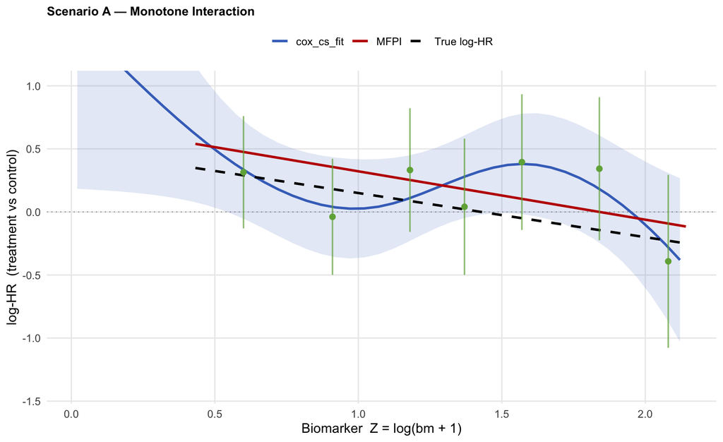

```r
plot_scenario(sim_res$monotone, "Scenario A — Monotone Interaction")
```

### 3.5 Scenario B — Threshold Interaction

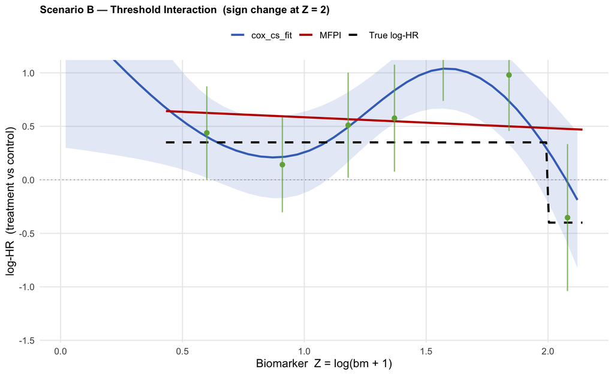

Scenario B: Sharp sign reversal at Z = 2. The spline smooths over the discontinuity, resulting in a biased estimate near the threshold. MFPI may select a degree-2 FP to better approximate the jump. STEPP windows that straddle Z = 2 are attenuated toward zero. None of the methods recovers the exact step — this scenario favours tree-based change-point methods.

```r
plot_scenario(sim_res$threshold,
              "Scenario B — Threshold Interaction  (sign change at Z = 2)")
```

### 3.6 Scenario C — Null Interaction

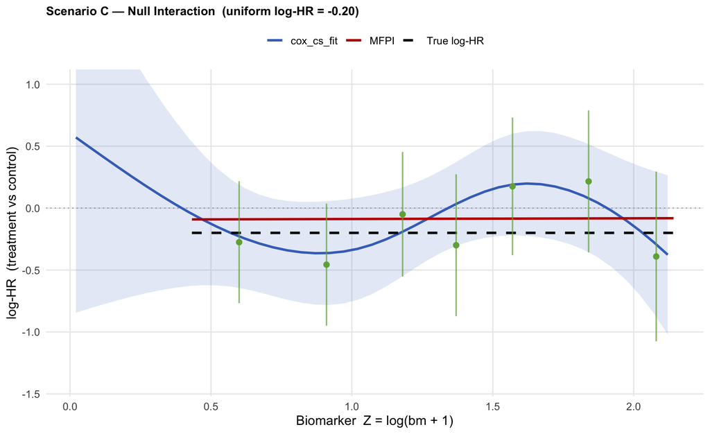

Scenario C: No interaction — uniform log-HR = -0.20. All methods should return approximately flat profiles. Residual curvature reflects sampling noise. The spline CI band should contain the flat line throughout.

```r
plot_scenario(sim_res$null,
              "Scenario C — Null Interaction  (uniform log-HR = -0.20)")
```

### 3.7 Point Estimates at the Biomarker Median

```r
summarise_at_z <- function(res, scenario, z_eval = 1.2) {
  # Extract the bare scenario name (strips prefix like "A: " if present)
  sc_key <- trimws(sub("^[A-Z]:\\s*", "", scenario))

  true_val <- switch(sc_key,
    Monotone  = ,
    monotone  = 0.5 - 0.35 * z_eval,
    Threshold = ,
    threshold = ifelse(z_eval < 2.0, 0.35, -0.40),
    Null      = ,
    null      = -0.20,
    stop("Unknown scenario key: ", sc_key)
  )

  cc_idx <- which.min(abs(res$ccsf$z  - z_eval))
  mf_idx <- which.min(abs(res$mfpi$z  - z_eval))
  st_idx <- which.min(abs(res$stepp$mid_bm - z_eval))

  data.frame(
    Scenario              = scenario,
    `True log-HR`         = round(true_val, 3),
    `cox_cs_fit Est.`     = round(res$ccsf$loghr[cc_idx], 3),
    `cox_cs_fit CI Wid.`  = round(res$ccsf$hi[cc_idx] - res$ccsf$lo[cc_idx], 3),
    `MFPI Est.`           = round(res$mfpi$loghr[mf_idx], 3),
    `STEPP Est.`          = round(res$stepp$loghr[st_idx], 3),
    `STEPP CI Wid.`       = round(res$stepp$hi[st_idx] - res$stepp$lo[st_idx], 3),
    check.names           = FALSE
  )
}

knitr::kable(
  bind_rows(
    summarise_at_z(sim_res$monotone,  "A: Monotone"),
    summarise_at_z(sim_res$threshold, "B: Threshold"),
    summarise_at_z(sim_res$null,      "C: Null")
  ),
  align = "lrrrrrrr"
)
```

Estimated log-HR at biomarker median (Z ≈ 1.2) for each scenario. cox_cs_fit CI width uses delta-method 95% interval; STEPP CI width uses 95% Wald CI per window.

| Scenario | True log-HR | cox_cs_fit Est. | cox_cs_fit CI Wid. | MFPI Est. | STEPP Est. | STEPP CI Wid. |
| --- | --- | --- | --- | --- | --- | --- |
| A: Monotone | 0.08 | 0.145 | 0.656 | 0.245 | 0.332 | 0.981 |
| B: Threshold | 0.35 | 0.567 | 0.625 | 0.564 | 0.510 | 0.983 |
| C: Null | -0.20 | -0.144 | 0.690 | -0.087 | -0.050 | 1.007 |

```r
# Evaluation grid: same for all scenarios; chosen to stay well within the
# z_quantile=0.95 prediction limit so every sim contributes at every point.
z_eval     <- c(0.6, 0.8, 1.0, 1.2, 1.4, 1.6, 1.8, 2.0)
B_eval     <- 5000L   # simulations per scenario
alpha_eval <- 0.05    # nominal CI level -> 95% coverage target
```

## 4 Simulation Evaluation of `cox_cs_fit()` Standard Errors and Coverage

### 4.1 Goals

At any prediction point $z$, `cox_cs_fit()` returns:

- $\hat\beta(z)$ — the estimated log-HR
- $\widehat{\text{SE}}(z)$ — the delta-method standard error
- $[\hat\beta_L(z),\, \hat\beta_U(z)]$ — the $(1-\alpha)$-level CI

Across $B =$ 5000 simulated trials we evaluate at a **fixed evaluation grid** `z_eval` (spanning the 10th–90th percentile of the biomarker distribution):

| Quantity | Definition |
| --- | --- |
| **Bias** | $\bar{\hat\beta}(z) - \beta_0(z)$ |
| **Empirical SE** | $\text{SD}_{b=1}^B\{\hat\beta_b(z)\}$ |
| **Mean estimated SE** | $B^{-1}\sum_b \widehat{\text{SE}}_b(z)$ |
| **SE ratio** | Mean estimated SE / Empirical SE (target: 1.0) |
| **Coverage** | $B^{-1}\sum_b \mathbf{1}\!\bigl[\beta_0(z)\in[\hat\beta_{Lb}(z),\hat\beta_{Ub}(z)]\bigr]$ (target: $1-\alpha = 0.95$) |

An SE ratio close to 1.0 means the delta-method variance is well-calibrated. Coverage below the nominal 95% may arise from **bias** (model misspecification) even when the SE ratio is correct — the threshold scenario is a designed test of this distinction.

### 4.2 Simulation Engine

```r
#' Evaluate cox_cs_fit() SE and coverage across B parallel simulations
#'
#' Uses \code{foreach \%dofuture\%} for parallelism.  Sets and restores the
#' \code{future} plan internally via \code{on.exit()} so the calling session
#' is always left in its original state, even if the function errors.
#'
#' @section Reproducibility:
#' Each iteration calls \code{set.seed(b)} inside the worker body, giving
#' results that are numerically identical to a sequential \code{for} loop.
#' \code{.options.future = list(seed = TRUE)} is specified to register
#' L'Ecuyer-CMRG streams with \pkg{doFuture} (suppressing the RNG-misuse
#' warning); \code{set.seed(b)} then immediately overrides the stream with
#' the deterministic per-iteration seed.
#'
#' @section Worker scoping:
#' \code{simulate_trial} is captured from the calling environment by
#' \pkg{future}'s globals scanner and exported automatically.
#' \code{cox_cs_fit} is loaded via \code{library(forestsearch)} inside each
#' worker — the package must be installed (not just \code{load_all()}'d).
#'
#' @param scenario  Character. "monotone", "threshold", or "null".
#' @param B         Integer.   Simulations per scenario.
#' @param z_eval    Numeric.   Fixed biomarker evaluation grid.
#' @param alpha     Numeric.   CI level passed to \code{cox_cs_fit()}.
#' @param n_workers Integer.   Parallel workers (default:
#'   \code{min(parallelly::availableCores(omit = 1L), 4L)}).
#' @return Named list: \code{summary} (data.frame of metrics),
#'   \code{mat_est}, \code{mat_se}, \code{mat_lo}, \code{mat_hi}
#'   (B x n_z matrices), \code{true_fn} (true log-HR at z_eval).
run_ccsf_eval <- function(scenario,
                          B         = 100L,
                          z_eval,
                          alpha     = 0.05,
                          n_workers = min(parallelly::availableCores(omit = 1L),
                                         4L)) {
  n_z <- length(z_eval)

  # ── Parallel plan — always restored on exit ────────────────────────────────
  old_plan <- plan()
  on.exit(plan(old_plan), add = TRUE)
  plan(multisession, workers = n_workers)

  message(sprintf("run_ccsf_eval [%s]: B = %d | workers = %d",
                  scenario, B, n_workers))

  # ── Parallel loop over B simulations ──────────────────────────────────────
  # .combine = "c" + list(out) wrapper: each iteration contributes one
  # element; foreach collects a flat list of length B.
  #
  # .options.future = list(seed = TRUE): registers L'Ecuyer-CMRG streams to
  # satisfy doFuture's RNG checker.  set.seed(b) inside the body then
  # overrides with our deterministic per-iteration seed, giving results
  # identical to a sequential for-loop.
  res_list <- foreach(
    b               = seq_len(B),
    .combine        = "c",
    .options.future = list(seed = TRUE)
  ) %dofuture% {
    set.seed(b)                    # deterministic per-iteration seed
    library(forestsearch)          # cox_cs_fit — must be installed
    library(survival)
    library(splines)

    d <- simulate_trial(scenario = scenario, seed = b)
    d$os_time  <- d$tte
    d$os_event <- d$event

    fit <- tryCatch(
      cox_cs_fit(
        df         = d,
        tte_name   = "os_time",
        event_name = "os_event",
        treat_name = "treat",
        z_name     = "Z",
        spline_df  = 3L,
        z_by       = 0.05,
        z_quantile = 0.95,
        alpha      = alpha,
        show_plot  = FALSE,
        verbose    = FALSE
      ),
      error = function(e) NULL
    )

    # NA-padded output: length = n_z regardless of profile coverage
    out <- list(est = rep(NA_real_, n_z),
                se  = rep(NA_real_, n_z),
                lo  = rep(NA_real_, n_z),
                hi  = rep(NA_real_, n_z))

    if (!is.null(fit)) {
      ok <- z_eval >= min(fit$z_profile) & z_eval <= max(fit$z_profile)
      if (any(ok)) {
        out$est[ok] <- approx(fit$z_profile, fit$loghr_est,   xout = z_eval[ok])$y
        out$se [ok] <- approx(fit$z_profile, fit$se_loghr,    xout = z_eval[ok])$y
        out$lo [ok] <- approx(fit$z_profile, fit$loghr_lower, xout = z_eval[ok])$y
        out$hi [ok] <- approx(fit$z_profile, fit$loghr_upper, xout = z_eval[ok])$y
      }
    }
    list(out)   # list() wrap keeps .combine="c" from unlisting the vectors
  }

  # ── Unpack list -> B x n_z matrices ───────────────────────────────────────
  mat_est <- do.call(rbind, lapply(res_list, `[[`, "est"))
  mat_se  <- do.call(rbind, lapply(res_list, `[[`, "se"))
  mat_lo  <- do.call(rbind, lapply(res_list, `[[`, "lo"))
  mat_hi  <- do.call(rbind, lapply(res_list, `[[`, "hi"))

  # ── Summary metrics ────────────────────────────────────────────────────────
  true_fn <- switch(scenario,
    monotone  = 0.5 - 0.35 * z_eval,
    threshold = ifelse(z_eval < 2.0, 0.35, -0.40),
    null      = rep(-0.20, n_z),
    stop("Unknown scenario: ", scenario)
  )

  covered <- sweep(mat_lo, 2, true_fn, "<=") &
             sweep(mat_hi, 2, true_fn, ">=")

  emp_se  <- apply(mat_est, 2, sd,    na.rm = TRUE)
  mean_se <- colMeans(mat_se,         na.rm = TRUE)

  summary_df <- data.frame(
    z          = z_eval,
    true_loghr = round(true_fn, 3),
    n_valid    = colSums(!is.na(mat_est)),
    bias       = round(colMeans(mat_est, na.rm = TRUE) - true_fn, 3),
    mean_est   = round(colMeans(mat_est, na.rm = TRUE), 3),
    emp_se     = round(emp_se,  3),
    mean_se    = round(mean_se, 3),
    se_ratio   = round(mean_se / emp_se, 3),
    coverage   = round(colMeans(covered, na.rm = TRUE), 3),
    scenario   = scenario,
    stringsAsFactors = FALSE
  )

  list(summary  = summary_df,
       mat_est  = mat_est,
       mat_se   = mat_se,
       mat_lo   = mat_lo,
       mat_hi   = mat_hi,
       true_fn  = true_fn)
}
```

### 4.3 Run Evaluation — All Three Scenarios

```r
t_eval_start <- proc.time()

eval_monotone  <- run_ccsf_eval("monotone",  B = B_eval, z_eval = z_eval, alpha = alpha_eval)
eval_threshold <- run_ccsf_eval("threshold", B = B_eval, z_eval = z_eval, alpha = alpha_eval)
eval_null      <- run_ccsf_eval("null",      B = B_eval, z_eval = z_eval, alpha = alpha_eval)

t_eval_sec <- round((proc.time() - t_eval_start)["elapsed"])
cat(sprintf(
  "Evaluation complete: B = %d per scenario | %d z-points | elapsed: %d sec\n",
  B_eval, length(z_eval), t_eval_sec
))
```

```
Evaluation complete: B = 5000 per scenario | 8 z-points | elapsed: 19 sec
```

```r
cat(sprintf("Nominal coverage: %.0f%%  (alpha = %.2f)\n",
            100 * (1 - alpha_eval), alpha_eval))
```

```
Nominal coverage: 95%  (alpha = 0.05)
```

### 4.4 Results Table

```r
all_eval <- bind_rows(
  eval_monotone$summary,
  eval_threshold$summary,
  eval_null$summary
) |>
  mutate(
    Scenario = case_match(scenario,
      "monotone"  ~ "A: Monotone",
      "threshold" ~ "B: Threshold",
      "null"      ~ "C: Null"
    )
  ) |>
  select(Scenario, z, true_loghr, mean_est, bias, emp_se, mean_se, se_ratio, coverage)

# Highlight off-target coverage
knitr::kable(
  all_eval,
  col.names = c("Scenario", "z", "log-HR", "Est", "Bias",
                "Emp SE", "Mean SE", "SE Ratio", "Coverage"),
  align     = "lrrrrrrrrr",
  digits    = 3
)
```

cox_cs_fit() SE and coverage evaluation across B = 5000 simulations at eight biomarker evaluation points. **Bias**: mean estimate minus truth. **Emp SE**: empirical standard deviation of estimates across simulations. **Mean SE**: mean of delta-method SE estimates. **SE ratio** (target ≈ 1.0): mean estimated SE / empirical SE. **Coverage** (target = 0.95): proportion of 95% CIs containing the true log-HR.

| Scenario | z | log-HR | Est | Bias | Emp SE | Mean SE | SE Ratio | Coverage |
| --- | --- | --- | --- | --- | --- | --- | --- | --- |
| A: Monotone | 0.6 | 0.29 | 0.444 | 0.154 | 0.220 | 0.216 | 0.979 | 0.894 |
| A: Monotone | 0.8 | 0.22 | 0.334 | 0.114 | 0.196 | 0.195 | 0.994 | 0.912 |
| A: Monotone | 1.0 | 0.15 | 0.226 | 0.076 | 0.200 | 0.199 | 0.998 | 0.931 |
| A: Monotone | 1.2 | 0.08 | 0.120 | 0.040 | 0.173 | 0.174 | 1.001 | 0.945 |
| A: Monotone | 1.4 | 0.01 | 0.017 | 0.007 | 0.175 | 0.174 | 0.996 | 0.949 |
| A: Monotone | 1.6 | -0.06 | -0.088 | -0.028 | 0.217 | 0.214 | 0.985 | 0.945 |
| A: Monotone | 1.8 | -0.13 | -0.197 | -0.067 | 0.233 | 0.227 | 0.977 | 0.937 |
| A: Monotone | 2.0 | -0.20 | -0.309 | -0.109 | 0.275 | 0.267 | 0.971 | 0.934 |
| B: Threshold | 0.6 | 0.35 | 0.514 | 0.164 | 0.218 | 0.214 | 0.980 | 0.882 |
| B: Threshold | 0.8 | 0.35 | 0.497 | 0.147 | 0.192 | 0.190 | 0.992 | 0.881 |
| B: Threshold | 1.0 | 0.35 | 0.506 | 0.156 | 0.194 | 0.193 | 0.993 | 0.874 |
| B: Threshold | 1.2 | 0.35 | 0.549 | 0.199 | 0.166 | 0.166 | 0.996 | 0.777 |
| B: Threshold | 1.4 | 0.35 | 0.587 | 0.237 | 0.163 | 0.162 | 0.998 | 0.694 |
| B: Threshold | 1.6 | 0.35 | 0.548 | 0.198 | 0.200 | 0.198 | 0.990 | 0.831 |
| B: Threshold | 1.8 | 0.35 | 0.381 | 0.031 | 0.213 | 0.209 | 0.984 | 0.944 |
| B: Threshold | 2.0 | -0.40 | 0.097 | 0.497 | 0.262 | 0.255 | 0.974 | 0.497 |
| C: Null | 0.6 | -0.20 | -0.304 | -0.104 | 0.248 | 0.243 | 0.977 | 0.929 |
| C: Null | 0.8 | -0.20 | -0.302 | -0.102 | 0.217 | 0.214 | 0.989 | 0.926 |
| C: Null | 1.0 | -0.20 | -0.300 | -0.100 | 0.219 | 0.219 | 0.996 | 0.932 |
| C: Null | 1.2 | -0.20 | -0.299 | -0.099 | 0.189 | 0.189 | 1.001 | 0.920 |
| C: Null | 1.4 | -0.20 | -0.299 | -0.099 | 0.184 | 0.183 | 0.995 | 0.914 |
| C: Null | 1.6 | -0.20 | -0.301 | -0.101 | 0.226 | 0.222 | 0.982 | 0.922 |
| C: Null | 1.8 | -0.20 | -0.304 | -0.104 | 0.241 | 0.235 | 0.975 | 0.927 |
| C: Null | 2.0 | -0.20 | -0.309 | -0.109 | 0.274 | 0.265 | 0.970 | 0.929 |

### 4.5 Coverage and SE Ratio Profiles

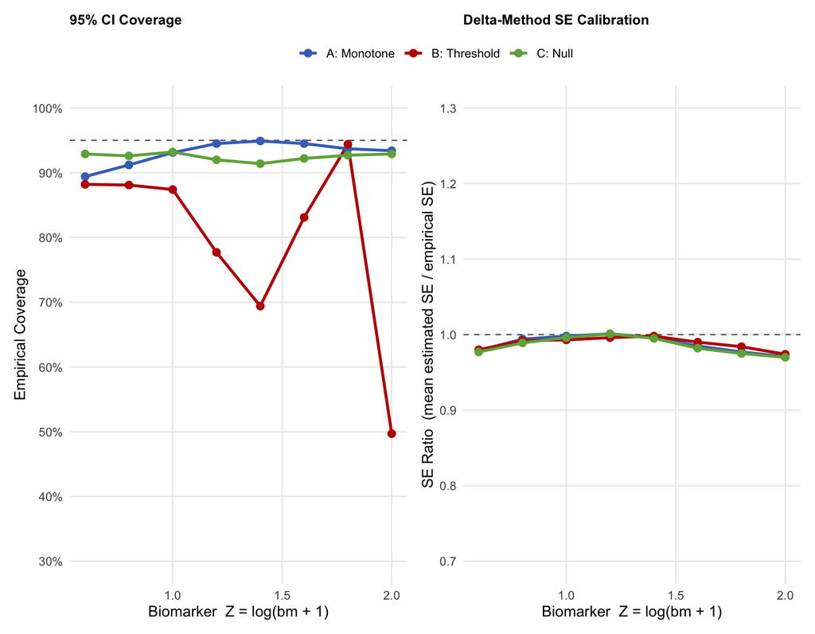

Left: Empirical coverage (solid) vs nominal 95% target (dashed) for each scenario. Coverage failure in Scenario B near the threshold is a bias artefact, not an SE failure. Right: SE ratio (mean estimated SE / empirical SE); values near 1.0 confirm delta-method calibration throughout.

```r
col_sc <- c("A: Monotone"  = "#4472C4",
            "B: Threshold" = "#C00000",
            "C: Null"      = "#70AD47")

df_plot <- all_eval |>
  mutate(Scenario = factor(Scenario,
                           levels = c("A: Monotone", "B: Threshold", "C: Null")))

p_cov <- ggplot(df_plot, aes(x = z, y = coverage, colour = Scenario)) +
  geom_hline(yintercept = 1 - alpha_eval, linetype = "dashed",
             colour = "grey40", linewidth = 0.5) +
  geom_line(linewidth = 1.1) +
  geom_point(size = 2.5) +
  scale_colour_manual(values = col_sc, name = NULL) +
  scale_y_continuous(limits = c(0.3, 1.0),
                     breaks = seq(0.3, 1.0, by = 0.1),
                     labels = scales::percent_format(accuracy = 1)) +
  labs(x = "Biomarker  Z = log(bm + 1)",
       y = "Empirical Coverage",
       title = "95% CI Coverage") +
  theme_minimal(base_size = 12) +
  theme(legend.position  = "top",
        panel.grid.minor = element_blank(),
        plot.title       = element_text(face = "bold", size = 11))

p_se <- ggplot(df_plot, aes(x = z, y = se_ratio, colour = Scenario)) +
  geom_hline(yintercept = 1, linetype = "dashed",
             colour = "grey40", linewidth = 0.5) +
  geom_line(linewidth = 1.1) +
  geom_point(size = 2.5) +
  scale_colour_manual(values = col_sc, name = NULL) +
  scale_y_continuous(limits = c(0.7, 1.3),
                     breaks = seq(0.7, 1.3, by = 0.1)) +
  labs(x = "Biomarker  Z = log(bm + 1)",
       y = "SE Ratio  (mean estimated SE / empirical SE)",
       title = "Delta-Method SE Calibration") +
  theme_minimal(base_size = 12) +
  theme(legend.position  = "top",
        panel.grid.minor = element_blank(),
        plot.title       = element_text(face = "bold", size = 11))

p_cov + p_se + plot_layout(ncol = 2, guides = "collect") &
  theme(legend.position = "top")
```

### 4.6 Simulation Envelopes for One Scenario

The plot below visualises the variability of the estimated log-HR profile across all $B =$ 5000 simulations for the **Monotone** scenario. The grey band is the pointwise 10th–90th percentile envelope; the bold blue line is the pointwise mean estimate; the dashed black line is the true log-HR.

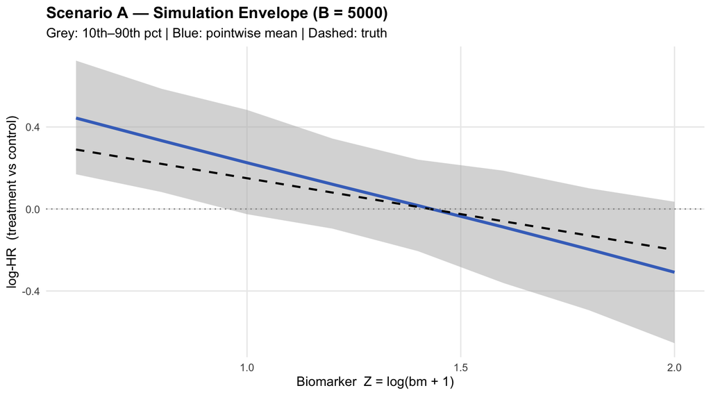

Pointwise simulation envelope for cox_cs_fit() under Scenario A (Monotone). Grey band: 10th–90th percentile of the 5000 estimated profiles. Bold: pointwise mean. Dashed: true log-HR.

```r
df_env <- data.frame(
  z    = z_eval,
  mean = colMeans(eval_monotone$mat_est, na.rm = TRUE),
  lo10 = apply(eval_monotone$mat_est, 2, quantile, 0.10, na.rm = TRUE),
  hi90 = apply(eval_monotone$mat_est, 2, quantile, 0.90, na.rm = TRUE),
  true = eval_monotone$true_fn
)

ggplot(df_env, aes(x = z)) +
  geom_ribbon(aes(ymin = lo10, ymax = hi90),
              fill = "grey70", alpha = 0.5) +
  geom_line(aes(y = mean),  colour = "#4472C4", linewidth = 1.3) +
  geom_line(aes(y = true),  colour = "black",   linewidth = 0.9,
            linetype = "dashed") +
  geom_hline(yintercept = 0, linetype = "dotted", colour = "grey55") +
  labs(x     = "Biomarker  Z = log(bm + 1)",
       y     = "log-HR  (treatment vs control)",
       title = sprintf("Scenario A — Simulation Envelope (B = %d)", B_eval),
       subtitle = "Grey: 10th–90th pct | Blue: pointwise mean | Dashed: truth") +
  theme_minimal(base_size = 12) +
  theme(panel.grid.minor = element_blank(),
        plot.title       = element_text(face = "bold"))
```

## 5 Method Comparison and Practical Guidance

### 5.1 Strengths and Limitations

**`cox_cs_fit()` (forestsearch)** is the recommended primary tool for continuous-biomarker evaluation in `forestsearch`. It wraps a natural-spline interaction Cox model with delta-method CIs in a single reproducible call, returns a structured list for downstream cut-point identification, and optionally produces a base-R diagnostic plot. The `spline_df`, `z_by`, `z_quantile`, and `alpha` arguments control resolution, range, and CI width.

**Manual Spline Cox** (Section 1b) exposes exactly the same model step-by-step for pedagogical purposes. The `cox_cs_fit()` and manual outputs should be numerically identical; any discrepancy reflects a difference in grid spacing (`z_by` vs. the manual `z_grid`).

**MFPI** is most useful when the interaction is expected to be monotone or of low polynomial degree. The data-adaptive power selection avoids knot-placement decisions entirely; in the monotone simulation it selected the exactly correct FP1 form. Its main limitation is computational: bootstrap CIs are required, and FP functions can oscillate in sparse biomarker tails.

**STEPP** (`stepp` CRAN package) provides a uniquely model-free visual diagnostic. The `stepp` package also delivers formal permutation tests for the supremum and chi-square heterogeneity statistics — something neither the spline nor MFPI approaches provide directly. Window parameter choices (`r1`, `r2`) govern both visual resolution and CI width.

### 5.2 Recommended Workflow

```
Step 1  cox_cs_fit()   Primary: smooth profile + delta-method CIs + LRT
Step 2  STEPP          Model-free check: flag threshold or U-shaped patterns;
                       permutation test for heterogeneity (stepp package)
Step 3  MFPI           Confirmatory: validate functional form of interaction
```

Convergent findings across all methods constitute strong evidence for a predictive biomarker. Divergence — e.g. STEPP reveals a pattern inconsistent with the spline — should trigger sensitivity analyses on `spline_df` and MFPI degree selection.

### 5.3 `cox_cs_fit()` Quick Reference

The call used in this vignette can be adapted directly from the GBSG example:

```r
library(forestsearch)

# Prepare GBSG — rename to match cox_cs_fit() parameter defaults
df_fs <- gbsg |>
  dplyr::rename(os_time  = rfstime_yr,
                os_event = status) |>
  dplyr::mutate(treat = hormon,
                bm    = log(pgr + 1))

# Fit the spline interaction Cox model
result <- cox_cs_fit(
  df         = df_fs,
  tte_name   = "os_time",
  event_name = "os_event",
  treat_name = "treat",
  z_name     = "bm",
  spline_df  = 3L,        # natural-spline df
  z_by       = 0.05,      # grid spacing (on biomarker scale)
  z_quantile = 0.95,      # upper endpoint of prediction grid
  alpha      = 0.05,      # 1-alpha CI
  show_plot  = TRUE,      # base-R plot
  verbose    = TRUE
)

# Key return slots
str(result[c("z_profile", "loghr_est", "loghr_lower", "loghr_upper",
             "cox_primary", "ci_level")])
```

## 6 References

Bonetti M, Gelber RD (2000). A graphical method to assess treatment-covariate interactions using the Cox model on subsets of the data. *Statistics in Medicine*, **19**, 2595–2609.

Lazar AA, Cole BF, Bonetti M, Gelber RD (2010). Evaluation of treatment-effect heterogeneity using biomarkers measured on a continuous scale: subpopulation treatment effect pattern plot. *Journal of Clinical Oncology*, **28**, 4539–4544.

Royston P, Sauerbrei W (2004). A new approach to modelling interactions between treatment and continuous covariates in clinical trials by using fractional polynomials. *Statistics in Medicine*, **23**, 2509–2525.

Royston P, Sauerbrei W (2008). Interactions between treatment and continuous covariates: a step towards individualizing therapy. *Journal of Clinical Oncology*, **26**, 1397–1399.

Royston P, Sauerbrei W (2013, 2014). Interaction of treatment with a continuous variable: simulation study of significance/power for several methods. *Statistics in Medicine*.

León LF et al. (2024). Exploratory subgroup identification in clinical trials with survival endpoints. *Statistics in Medicine*, doi:10.1002/sim.10163.